# Predict Bike Sharing Demand with AutoGluon Template

## Project: Predict Bike Sharing Demand with AutoGluon

This notebook is a template with each step that you need to complete for the project.

Please fill in your code where there are explicit `?` markers in the notebook. You are welcome to add more cells and code as you see fit.

Once you have completed all the code implementations, please export your notebook as a HTML file so the reviews can view your code. Make sure you have all outputs correctly outputted.

`File-> Export Notebook As... -> Export Notebook as HTML`

There is a writeup to complete as well after all code implememtation is done. Please answer all questions and attach the necessary tables and charts. You can complete the writeup in either markdown or PDF.

Completing the code template and writeup template will cover all of the rubric points for this project.

The rubric contains "Stand Out Suggestions" for enhancing the project beyond the minimum requirements. The stand out suggestions are optional. If you decide to pursue the "stand out suggestions", you can include the code in this notebook and also discuss the results in the writeup file.

## Step 1: Create an account with Kaggle

### Create Kaggle Account and download API key

Below is example of steps to get the API username and key. Each student will have their own username and key.

1. Open account settings.

2. Scroll down to API and click Create New API Token.

3. Open up `kaggle.json` and use the username and key.


## Step 2: Download the Kaggle dataset using the kaggle python library

### Install packages

```python
!pip install -U pip
!pip install -U setuptools wheel
!pip install -U "mxnet<2.0.0" bokeh==2.0.1
!pip install autogluon --no-cache-dir
# Without --no-cache-dir, smaller aws instances may have trouble installing
```

[output not shown]

[output cut: 70 more lines]

[output not shown]

### Setup Kaggle API Key

```python
!mkdir -p /home/sagemaker-user/.kaggle
!touch /home/sagemaker-user/.kaggle/kaggle.json
!chmod 600 /home/sagemaker-user/.kaggle/kaggle.json
```

```python
!pwd
```

```
/home/sagemaker-user/cd0385-project-starter/project
```

```python
# create the .kaggle directory and an empty kaggle.json file
!mkdir -p /root/.kaggle
!touch /root/.kaggle/kaggle.json
!chmod 600 /root/.kaggle/kaggle.json
```

```python
# Fill in your user name and key from creating the kaggle account and API token file
import json
kaggle_username = "hkjunhong"
kaggle_key = "01b948f9aeef1753c64f2962aa1449b7"

# Save API token the kaggle.json file
with open("/home/sagemaker-user/.kaggle/kaggle.json", "w") as f:
    f.write(json.dumps({"username": kaggle_username, "key": kaggle_key}))
```

### Download and explore dataset

### Go to the bike sharing demand competition and agree to the terms

```python
!pip install kaggle
```

```
  Using cached kaggle-1.6.14-py3-none-any.whl
```

```python
# Download the dataset, it will be in a .zip file so you'll need to unzip it as well.
!kaggle competitions download -c bike-sharing-demand
# If you already downloaded it you can use the -o command to overwrite the file
!unzip -o bike-sharing-demand.zip
```

```
Downloading bike-sharing-demand.zip to /home/sagemaker-user/cd0385-project-starter/project
Archive:  bike-sharing-demand.zip
  inflating: sampleSubmission.csv
  inflating: test.csv
  inflating: train.csv
```

```python
import pandas as pd
from autogluon.tabular import TabularPredictor
```

```python
# Create the train dataset in pandas by reading the csv
# Set the parsing of the datetime column so you can use some of the `dt` features in pandas later
train = pd.read_csv("train.csv")
train["datetime"]=pd.to_datetime(train["datetime"])
train.head()
```

|  | datetime | season | holiday | workingday | weather | temp | atemp | humidity | windspeed | casual | registered | count |
| --- | --- | --- | --- | --- | --- | --- | --- | --- | --- | --- | --- | --- |
| 0 | 2011-01-01 00:00:00 | 1 | 0 | 0 | 1 | 9.84 | 14.395 | 81 | 0.0 | 3 | 13 | 16 |
| 1 | 2011-01-01 01:00:00 | 1 | 0 | 0 | 1 | 9.02 | 13.635 | 80 | 0.0 | 8 | 32 | 40 |
| 2 | 2011-01-01 02:00:00 | 1 | 0 | 0 | 1 | 9.02 | 13.635 | 80 | 0.0 | 5 | 27 | 32 |
| 3 | 2011-01-01 03:00:00 | 1 | 0 | 0 | 1 | 9.84 | 14.395 | 75 | 0.0 | 3 | 10 | 13 |
| 4 | 2011-01-01 04:00:00 | 1 | 0 | 0 | 1 | 9.84 | 14.395 | 75 | 0.0 | 0 | 1 | 1 |

```python
train.describe()
```

|  | datetime | season | holiday | workingday | weather | temp | atemp | humidity | windspeed | casual | registered | count |
| --- | --- | --- | --- | --- | --- | --- | --- | --- | --- | --- | --- | --- |
| count | 10886 | 10886.000000 | 10886.000000 | 10886.000000 | 10886.000000 | 10886.00000 | 10886.000000 | 10886.000000 | 10886.000000 | 10886.000000 | 10886.000000 | 10886.000000 |
| mean | 2011-12-27 05:56:22.399411968 | 2.506614 | 0.028569 | 0.680875 | 1.418427 | 20.23086 | 23.655084 | 61.886460 | 12.799395 | 36.021955 | 155.552177 | 191.574132 |
| min | 2011-01-01 00:00:00 | 1.000000 | 0.000000 | 0.000000 | 1.000000 | 0.82000 | 0.760000 | 0.000000 | 0.000000 | 0.000000 | 0.000000 | 1.000000 |
| 25% | 2011-07-02 07:15:00 | 2.000000 | 0.000000 | 0.000000 | 1.000000 | 13.94000 | 16.665000 | 47.000000 | 7.001500 | 4.000000 | 36.000000 | 42.000000 |
| 50% | 2012-01-01 20:30:00 | 3.000000 | 0.000000 | 1.000000 | 1.000000 | 20.50000 | 24.240000 | 62.000000 | 12.998000 | 17.000000 | 118.000000 | 145.000000 |
| 75% | 2012-07-01 12:45:00 | 4.000000 | 0.000000 | 1.000000 | 2.000000 | 26.24000 | 31.060000 | 77.000000 | 16.997900 | 49.000000 | 222.000000 | 284.000000 |
| max | 2012-12-19 23:00:00 | 4.000000 | 1.000000 | 1.000000 | 4.000000 | 41.00000 | 45.455000 | 100.000000 | 56.996900 | 367.000000 | 886.000000 | 977.000000 |
| std | NaN | 1.116174 | 0.166599 | 0.466159 | 0.633839 | 7.79159 | 8.474601 | 19.245033 | 8.164537 | 49.960477 | 151.039033 | 181.144454 |

```python
# Create the test pandas dataframe in pandas by reading the csv, remember to parse the datetime!
test = pd.read_csv("test.csv")
test["datetime"] = pd.to_datetime(test["datetime"])
test.head()
```

|  | datetime | season | holiday | workingday | weather | temp | atemp | humidity | windspeed |
| --- | --- | --- | --- | --- | --- | --- | --- | --- | --- |
| 0 | 2011-01-20 00:00:00 | 1 | 0 | 1 | 1 | 10.66 | 11.365 | 56 | 26.0027 |
| 1 | 2011-01-20 01:00:00 | 1 | 0 | 1 | 1 | 10.66 | 13.635 | 56 | 0.0000 |
| 2 | 2011-01-20 02:00:00 | 1 | 0 | 1 | 1 | 10.66 | 13.635 | 56 | 0.0000 |
| 3 | 2011-01-20 03:00:00 | 1 | 0 | 1 | 1 | 10.66 | 12.880 | 56 | 11.0014 |
| 4 | 2011-01-20 04:00:00 | 1 | 0 | 1 | 1 | 10.66 | 12.880 | 56 | 11.0014 |

```python
# Same thing as train and test dataset
submission = pd.read_csv("sampleSubmission.csv")
submission.head()
```

|  | datetime | count |
| --- | --- | --- |
| 0 | 2011-01-20 00:00:00 | 0 |
| 1 | 2011-01-20 01:00:00 | 0 |
| 2 | 2011-01-20 02:00:00 | 0 |
| 3 | 2011-01-20 03:00:00 | 0 |
| 4 | 2011-01-20 04:00:00 | 0 |

## Step 3: Train a model using AutoGluon"s Tabular Prediction

Requirements:

- We are prediting `count`, so it is the label we are setting.
- Ignore `casual` and `registered` columns as they are also not present in the test dataset.
- Use the `root_mean_squared_error` as the metric to use for evaluation.
- Set a time limit of 10 minutes (600 seconds).
- Use the preset `best_quality` to focus on creating the best model.

```python
train = train.drop(["casual","registered"],axis=1)
train.head()
train.describe()
```

|  | datetime | season | holiday | workingday | weather | temp | atemp | humidity | windspeed | count |
| --- | --- | --- | --- | --- | --- | --- | --- | --- | --- | --- |
| count | 10886 | 10886.000000 | 10886.000000 | 10886.000000 | 10886.000000 | 10886.00000 | 10886.000000 | 10886.000000 | 10886.000000 | 10886.000000 |
| mean | 2011-12-27 05:56:22.399411968 | 2.506614 | 0.028569 | 0.680875 | 1.418427 | 20.23086 | 23.655084 | 61.886460 | 12.799395 | 191.574132 |
| min | 2011-01-01 00:00:00 | 1.000000 | 0.000000 | 0.000000 | 1.000000 | 0.82000 | 0.760000 | 0.000000 | 0.000000 | 1.000000 |
| 25% | 2011-07-02 07:15:00 | 2.000000 | 0.000000 | 0.000000 | 1.000000 | 13.94000 | 16.665000 | 47.000000 | 7.001500 | 42.000000 |
| 50% | 2012-01-01 20:30:00 | 3.000000 | 0.000000 | 1.000000 | 1.000000 | 20.50000 | 24.240000 | 62.000000 | 12.998000 | 145.000000 |
| 75% | 2012-07-01 12:45:00 | 4.000000 | 0.000000 | 1.000000 | 2.000000 | 26.24000 | 31.060000 | 77.000000 | 16.997900 | 284.000000 |
| max | 2012-12-19 23:00:00 | 4.000000 | 1.000000 | 1.000000 | 4.000000 | 41.00000 | 45.455000 | 100.000000 | 56.996900 | 977.000000 |
| std | NaN | 1.116174 | 0.166599 | 0.466159 | 0.633839 | 7.79159 | 8.474601 | 19.245033 | 8.164537 | 181.144454 |

```
No path specified. Models will be saved in: "AutogluonModels/ag-20240617_120842/"
Presets specified: ['best_quality']
Stack configuration (auto_stack=True): num_stack_levels=1, num_bag_folds=8, num_bag_sets=20
Beginning AutoGluon training ... Time limit = 600s
AutoGluon will save models to "AutogluonModels/ag-20240617_120842/"
AutoGluon Version:  0.8.3
Python Version:     3.10.14
Operating System:   Linux
Platform Machine:   x86_64
Platform Version:   #1 SMP Fri May 17 18:07:48 UTC 2024
Disk Space Avail:   5.16 GB / 5.36 GB (96.3%)
	WARNING: Available disk space is low and there is a risk that AutoGluon will run out of disk during fit, causing an exception.
	We recommend a minimum available disk space of 10 GB, and large datasets may require more.
Train Data Rows:    10886
Train Data Columns: 9
Label Column: count
Preprocessing data ...
AutoGluon infers your prediction problem is: 'regression' (because dtype of label-column == int and many unique label-values observed).
	Label info (max, min, mean, stddev): (977, 1, 191.57413, 181.14445)
	If 'regression' is not the correct problem_type, please manually specify the problem_type parameter during predictor init (You may specify problem_type as one of: ['binary', 'multiclass', 'regression'])
Using Feature Generators to preprocess the data ...
Fitting AutoMLPipelineFeatureGenerator...
	Available Memory:                    2298.95 MB
	Train Data (Original)  Memory Usage: 0.78 MB (0.0% of available memory)
	Inferring data type of each feature based on column values. Set feature_metadata_in to manually specify special dtypes of the features.
	Stage 1 Generators:
		Fitting AsTypeFeatureGenerator...
			Note: Converting 2 features to boolean dtype as they only contain 2 unique values.
	Stage 2 Generators:
		Fitting FillNaFeatureGenerator...
	Stage 3 Generators:
		Fitting IdentityFeatureGenerator...
		Fitting DatetimeFeatureGenerator...
	Stage 4 Generators:
		Fitting DropUniqueFeatureGenerator...
	Stage 5 Generators:
		Fitting DropDuplicatesFeatureGenerator...
	Types of features in original data (raw dtype, special dtypes):
		('datetime', []) : 1 | ['datetime']
		('float', [])    : 3 | ['temp', 'atemp', 'windspeed']
```

[output cut: 28 more lines]

[output not shown]

```
[1000]	valid_set's rmse: 131.684
[2000]	valid_set's rmse: 130.67
[3000]	valid_set's rmse: 130.626
[1000]	valid_set's rmse: 135.592
[1000]	valid_set's rmse: 133.481
[2000]	valid_set's rmse: 132.323
[3000]	valid_set's rmse: 131.618
[4000]	valid_set's rmse: 131.443
[5000]	valid_set's rmse: 131.265
[6000]	valid_set's rmse: 131.277
[7000]	valid_set's rmse: 131.443
[1000]	valid_set's rmse: 128.503
[2000]	valid_set's rmse: 127.654
[3000]	valid_set's rmse: 127.227
[4000]	valid_set's rmse: 127.105
[1000]	valid_set's rmse: 134.135
[2000]	valid_set's rmse: 132.272
[3000]	valid_set's rmse: 131.286
[4000]	valid_set's rmse: 130.752
[5000]	valid_set's rmse: 130.363
[6000]	valid_set's rmse: 130.509
[1000]	valid_set's rmse: 136.168
[2000]	valid_set's rmse: 135.138
[3000]	valid_set's rmse: 135.029
[1000]	valid_set's rmse: 134.061
[2000]	valid_set's rmse: 133.034
[3000]	valid_set's rmse: 132.182
[4000]	valid_set's rmse: 131.997
[5000]	valid_set's rmse: 131.643
[6000]	valid_set's rmse: 131.504
[7000]	valid_set's rmse: 131.574
[1000]	valid_set's rmse: 132.912
[2000]	valid_set's rmse: 131.703
[3000]	valid_set's rmse: 131.117
[4000]	valid_set's rmse: 130.82
[5000]	valid_set's rmse: 130.673
[6000]	valid_set's rmse: 130.708
```

```
	-131.4609	 = Validation score   (-root_mean_squared_error)
	49.47s	 = Training   runtime
	6.08s	 = Validation runtime
Fitting model: LightGBM_BAG_L1 ... Training model for up to 333.86s of the 533.89s of remaining time.
	Fitting 8 child models (S1F1 - S1F8) | Fitting with SequentialLocalFoldFittingStrategy
```

```
[1000]	valid_set's rmse: 130.818
[1000]	valid_set's rmse: 133.204
[1000]	valid_set's rmse: 130.928
[1000]	valid_set's rmse: 126.846
[1000]	valid_set's rmse: 131.426
[1000]	valid_set's rmse: 133.655
[1000]	valid_set's rmse: 132.155
[1000]	valid_set's rmse: 130.62
```

```
	-131.0542	 = Validation score   (-root_mean_squared_error)
	20.84s	 = Training   runtime
	1.69s	 = Validation runtime
Fitting model: RandomForestMSE_BAG_L1 ... Training model for up to 308.37s of the 508.4s of remaining time.
	-116.5484	 = Validation score   (-root_mean_squared_error)
	27.47s	 = Training   runtime
	1.11s	 = Validation runtime
Fitting model: CatBoost_BAG_L1 ... Training model for up to 278.83s of the 478.86s of remaining time.
	Fitting 8 child models (S1F1 - S1F8) | Fitting with SequentialLocalFoldFittingStrategy
	Ran out of time, early stopping on iteration 2844.
	Ran out of time, early stopping on iteration 2985.
	Ran out of time, early stopping on iteration 3168.
	Ran out of time, early stopping on iteration 3732.
	Ran out of time, early stopping on iteration 3920.
	Ran out of time, early stopping on iteration 5096.
	-130.7414	 = Validation score   (-root_mean_squared_error)
	226.28s	 = Training   runtime
	0.11s	 = Validation runtime
Fitting model: ExtraTreesMSE_BAG_L1 ... Training model for up to 52.31s of the 252.35s of remaining time.
	-124.6007	 = Validation score   (-root_mean_squared_error)
	8.13s	 = Training   runtime
	0.66s	 = Validation runtime
Fitting model: NeuralNetFastAI_BAG_L1 ... Training model for up to 42.98s of the 243.01s of remaining time.
	Fitting 8 child models (S1F1 - S1F8) | Fitting with SequentialLocalFoldFittingStrategy
	Ran out of time, stopping training early. (Stopping on epoch 6)
	Ran out of time, stopping training early. (Stopping on epoch 7)
	Ran out of time, stopping training early. (Stopping on epoch 6)
	Ran out of time, stopping training early. (Stopping on epoch 9)
	Ran out of time, stopping training early. (Stopping on epoch 7)
	-140.026	 = Validation score   (-root_mean_squared_error)
	39.81s	 = Training   runtime
	0.26s	 = Validation runtime
Fitting model: XGBoost_BAG_L1 ... Training model for up to 2.77s of the 202.81s of remaining time.
	Fitting 8 child models (S1F1 - S1F8) | Fitting with SequentialLocalFoldFittingStrategy
	-132.9798	 = Validation score   (-root_mean_squared_error)
	2.56s	 = Training   runtime
	0.11s	 = Validation runtime
Fitting model: NeuralNetTorch_BAG_L1 ... Training model for up to 0.04s of the 200.07s of remaining time.
	Fitting 8 child models (S1F1 - S1F8) | Fitting with SequentialLocalFoldFittingStrategy
	Time limit exceeded... Skipping NeuralNetTorch_BAG_L1.
Completed 1/20 k-fold bagging repeats ...
Fitting model: WeightedEnsemble_L2 ... Training model for up to 360.0s of the 199.95s of remaining time.
	-84.1251	 = Validation score   (-root_mean_squared_error)
	0.38s	 = Training   runtime
	0.0s	 = Validation runtime
Fitting 9 L2 models ...
Fitting model: LightGBMXT_BAG_L2 ... Training model for up to 199.56s of the 199.55s of remaining time.
	Fitting 8 child models (S1F1 - S1F8) | Fitting with SequentialLocalFoldFittingStrategy
```

```
[1000]	valid_set's rmse: 60.3477
[2000]	valid_set's rmse: 59.2253
[3000]	valid_set's rmse: 59.1505
[1000]	valid_set's rmse: 60.2387
[2000]	valid_set's rmse: 59.3679
[1000]	valid_set's rmse: 63.6081
[2000]	valid_set's rmse: 62.5526
[1000]	valid_set's rmse: 63.3504
[2000]	valid_set's rmse: 61.6185
[3000]	valid_set's rmse: 61.4426
[4000]	valid_set's rmse: 61.4982
[1000]	valid_set's rmse: 58.4648
[2000]	valid_set's rmse: 57.3982
[1000]	valid_set's rmse: 63.6309
[2000]	valid_set's rmse: 62.6082
[1000]	valid_set's rmse: 63.2868
[2000]	valid_set's rmse: 62.0431
[3000]	valid_set's rmse: 61.8175
[1000]	valid_set's rmse: 58.0437
[2000]	valid_set's rmse: 57.2772
```

```
	-60.1628	 = Validation score   (-root_mean_squared_error)
	54.41s	 = Training   runtime
	3.94s	 = Validation runtime
Fitting model: LightGBM_BAG_L2 ... Training model for up to 136.06s of the 136.04s of remaining time.
	Fitting 8 child models (S1F1 - S1F8) | Fitting with SequentialLocalFoldFittingStrategy
	-55.015	 = Validation score   (-root_mean_squared_error)
	18.9s	 = Training   runtime
	0.32s	 = Validation runtime
Fitting model: RandomForestMSE_BAG_L2 ... Training model for up to 116.38s of the 116.36s of remaining time.
	-53.2846	 = Validation score   (-root_mean_squared_error)
	69.73s	 = Training   runtime
	1.17s	 = Validation runtime
Fitting model: CatBoost_BAG_L2 ... Training model for up to 44.58s of the 44.57s of remaining time.
	Fitting 8 child models (S1F1 - S1F8) | Fitting with SequentialLocalFoldFittingStrategy
	Ran out of time, early stopping on iteration 522.
	Ran out of time, early stopping on iteration 645.
	Ran out of time, early stopping on iteration 678.
	Ran out of time, early stopping on iteration 768.
	Ran out of time, early stopping on iteration 821.
	Ran out of time, early stopping on iteration 828.
	Ran out of time, early stopping on iteration 886.
	Ran out of time, early stopping on iteration 1123.
	-55.9059	 = Validation score   (-root_mean_squared_error)
	42.73s	 = Training   runtime
	0.05s	 = Validation runtime
Fitting model: ExtraTreesMSE_BAG_L2 ... Training model for up to 1.73s of the 1.72s of remaining time.
	-53.951	 = Validation score   (-root_mean_squared_error)
	14.79s	 = Training   runtime
	0.67s	 = Validation runtime
Completed 1/20 k-fold bagging repeats ...
Fitting model: WeightedEnsemble_L3 ... Training model for up to 360.0s of the -14.2s of remaining time.
	-52.807	 = Validation score   (-root_mean_squared_error)
	0.24s	 = Training   runtime
	0.0s	 = Validation runtime
AutoGluon training complete, total runtime = 614.46s ... Best model: "WeightedEnsemble_L3"
TabularPredictor saved. To load, use: predictor = TabularPredictor.load("AutogluonModels/ag-20240617_120842/")
```

```
                     model   score_val  pred_time_val    fit_time  pred_time_val_marginal  fit_time_marginal  stack_level  can_infer  fit_order
0      WeightedEnsemble_L3  -52.806980      12.284101  478.304582                0.000540           0.243409            3       True         16
1   RandomForestMSE_BAG_L2  -53.284646      11.299760  444.375963                1.165724          69.732268            2       True         13
2     ExtraTreesMSE_BAG_L2  -53.950967      10.799661  389.431713                0.665624          14.788018            2       True         15
3          LightGBM_BAG_L2  -55.014954      10.452213  393.540886                0.318176          18.897192            2       True         12
4          CatBoost_BAG_L2  -55.905909      10.184499  417.371571                0.050463          42.727876            2       True         14
5        LightGBMXT_BAG_L2  -60.162763      14.075648  429.054475                3.941611          54.410781            2       True         11
6    KNeighborsDist_BAG_L1  -84.125061       0.063820    0.034197                0.063820           0.034197            1       True          2
7      WeightedEnsemble_L2  -84.125061       0.064475    0.410889                0.000654           0.376692            2       True         10
8    KNeighborsUnif_BAG_L1 -101.546199       0.065897    0.042667                0.065897           0.042667            1       True          1
9   RandomForestMSE_BAG_L1 -116.548359       1.106647   27.473886                1.106647          27.473886            1       True          5
10    ExtraTreesMSE_BAG_L1 -124.600676       0.658323    8.128919                0.658323           8.128919            1       True          7
11         CatBoost_BAG_L1 -130.741361       0.107749  226.281106                0.107749         226.281106            1       True          6
12         LightGBM_BAG_L1 -131.054162       1.685238   20.840734                1.685238          20.840734            1       True          4
13       LightGBMXT_BAG_L1 -131.460909       6.079871   49.473302                6.079871          49.473302            1       True          3
14          XGBoost_BAG_L1 -132.979777       0.110361    2.560890                0.110361           2.560890            1       True          9
15  NeuralNetFastAI_BAG_L1 -140.025971       0.256130   39.807991                0.256130          39.807991            1       True          8
```

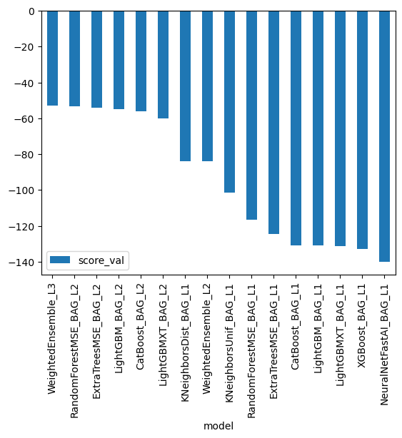

```python
predictor = TabularPredictor("count",eval_metric="root_mean_squared_error").fit(
    train_data = train,
    time_limit = 600,
    presets="best_quality"
)
predictor.leaderboard().plot(x="model",y="score_val",kind="bar")
```

```python
predictions = predictor.predict(test)
predictions.head()
```

```
0    23.295076
1    41.468395
2    45.402748
3    48.622532
4    51.853073
Name: count, dtype: float32
```

```python
sum (predictions<0)
```

```
0
```

```python
# Set them to zero
predictions[predictions<0] = 0
```

### Set predictions to submission dataframe, save, and submit

```python
submission["count"] = predictions
submission.to_csv("submission.csv", index=False)
```

```python
!pip install kaggle
```

```
  Using cached kaggle-1.6.14-py3-none-any.whl
```

```python
!kaggle competitions submit -c bike-sharing-demand -f submission.csv -m "first raw submission"
```

```
Successfully submitted to Bike Sharing Demand
```

#### View submission via the command line or in the web browser under the competition's page - `My Submissions`

```python
!kaggle competitions submissions -c bike-sharing-demand | tail -n +1 | head -n 6
```

```
fileName                     date                 description           status    publicScore  privateScore
---------------------------  -------------------  --------------------  --------  -----------  ------------
submission.csv               2024-06-17 12:20:08  first raw submission  complete  1.79989      1.79989
submission.csv               2024-06-17 10:47:03  first raw submission  complete  1.84007      1.84007
submission_hpo.csv           2024-06-04 09:59:54  new features          complete  0.78794      0.78794
submission_hpo.csv           2024-06-03 10:48:11  new features          complete  0.59997      0.59997
```

## Step 4: Exploratory Data Analysis and Creating an additional feature

- Any additional feature will do, but a great suggestion would be to separate out the datetime into hour, day, or month parts.

```
array([[<Axes: title={'center': 'datetime'}>,
        <Axes: title={'center': 'season'}>,
        <Axes: title={'center': 'holiday'}>],
       [<Axes: title={'center': 'workingday'}>,
        <Axes: title={'center': 'weather'}>,
        <Axes: title={'center': 'temp'}>],
       [<Axes: title={'center': 'atemp'}>,
        <Axes: title={'center': 'humidity'}>,
        <Axes: title={'center': 'windspeed'}>]], dtype=object)
```

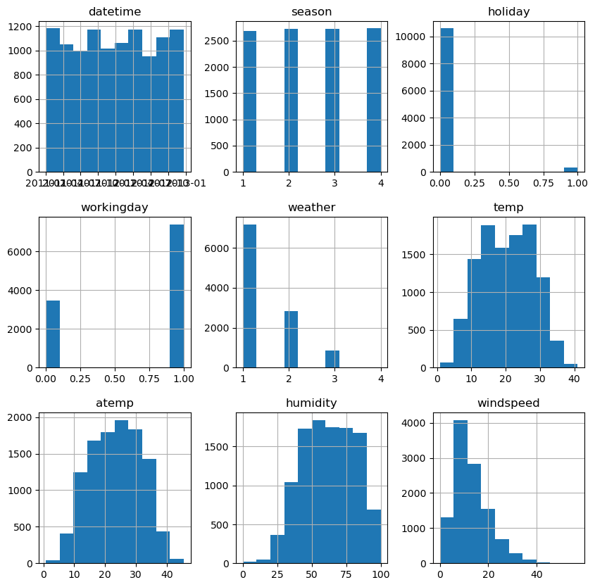

```python
# Create a histogram of all features to show the distribution of each one relative to the data. This is part of the exploritory data analysis
train.drop(["count"],axis=1).hist(figsize=(10,10))
```

```python
# create a new feature
train["year"] = train["datetime"].dt.year
train["month"] = train["datetime"].dt.year
train["day"] = train["datetime"].dt.day
train["hour"] = train["datetime"].dt.hour
test["year"] = test["datetime"].dt.year
test["month"] = test["datetime"].dt.year
test["day"] = test["datetime"].dt.day
test["hour"] = test["datetime"].dt.hour
```

## Make category types for these so models know they are not just numbers

- AutoGluon originally sees these as ints, but in reality they are int representations of a category.
- Setting the dtype to category will classify these as categories in AutoGluon.

```python
train["season"] = train["season"].astype("category")
train["weather"] = train["weather"].astype("category")
test["season"] = test["season"].astype("category")
test["weather"] = test["weather"].astype("category")
train = train.drop(["datetime"],axis=1)
test = test.drop(["datetime"],axis=1)
```

```python
# View are new feature
train.head()
```

|  | season | holiday | workingday | weather | temp | atemp | humidity | windspeed | count | year | month | day | hour |
| --- | --- | --- | --- | --- | --- | --- | --- | --- | --- | --- | --- | --- | --- |
| 0 | 1 | 0 | 0 | 1 | 9.84 | 14.395 | 81 | 0.0 | 16 | 2011 | 2011 | 1 | 0 |
| 1 | 1 | 0 | 0 | 1 | 9.02 | 13.635 | 80 | 0.0 | 40 | 2011 | 2011 | 1 | 1 |
| 2 | 1 | 0 | 0 | 1 | 9.02 | 13.635 | 80 | 0.0 | 32 | 2011 | 2011 | 1 | 2 |
| 3 | 1 | 0 | 0 | 1 | 9.84 | 14.395 | 75 | 0.0 | 13 | 2011 | 2011 | 1 | 3 |
| 4 | 1 | 0 | 0 | 1 | 9.84 | 14.395 | 75 | 0.0 | 1 | 2011 | 2011 | 1 | 4 |

|  | season | holiday | workingday | weather | temp | atemp | humidity | windspeed | count | year | month | day | hour |
| --- | --- | --- | --- | --- | --- | --- | --- | --- | --- | --- | --- | --- | --- |
| season | 1.000000 | 0.029368 | -0.008126 | 0.008879 | 0.258689 | 0.264744 | 0.190610 | -0.147121 | 0.163439 | -0.004797 | -0.004797 | 0.001729 | -0.006546 |
| holiday | 0.029368 | 1.000000 | -0.250491 | -0.007074 | 0.000295 | -0.005215 | 0.001929 | 0.008409 | -0.005393 | 0.012021 | 0.012021 | -0.015877 | -0.000354 |
| workingday | -0.008126 | -0.250491 | 1.000000 | 0.033772 | 0.029966 | 0.024660 | -0.010880 | 0.013373 | 0.011594 | -0.002482 | -0.002482 | 0.009829 | 0.002780 |
| weather | 0.008879 | -0.007074 | 0.033772 | 1.000000 | -0.055035 | -0.055376 | 0.406244 | 0.007261 | -0.128655 | -0.012548 | -0.012548 | -0.007890 | -0.022740 |
| temp | 0.258689 | 0.000295 | 0.029966 | -0.055035 | 1.000000 | 0.984948 | -0.064949 | -0.017852 | 0.394454 | 0.061226 | 0.061226 | 0.015551 | 0.145430 |
| atemp | 0.264744 | -0.005215 | 0.024660 | -0.055376 | 0.984948 | 1.000000 | -0.043536 | -0.057473 | 0.389784 | 0.058540 | 0.058540 | 0.011866 | 0.140343 |
| humidity | 0.190610 | 0.001929 | -0.010880 | 0.406244 | -0.064949 | -0.043536 | 1.000000 | -0.318607 | -0.317371 | -0.078606 | -0.078606 | -0.011335 | -0.278011 |
| windspeed | -0.147121 | 0.008409 | 0.013373 | 0.007261 | -0.017852 | -0.057473 | -0.318607 | 1.000000 | 0.101369 | -0.015221 | -0.015221 | 0.036157 | 0.146631 |
| count | 0.163439 | -0.005393 | 0.011594 | -0.128655 | 0.394454 | 0.389784 | -0.317371 | 0.101369 | 1.000000 | 0.260403 | 0.260403 | 0.019826 | 0.400601 |
| year | -0.004797 | 0.012021 | -0.002482 | -0.012548 | 0.061226 | 0.058540 | -0.078606 | -0.015221 | 0.260403 | 1.000000 | 1.000000 | 0.001800 | -0.004234 |
| month | -0.004797 | 0.012021 | -0.002482 | -0.012548 | 0.061226 | 0.058540 | -0.078606 | -0.015221 | 0.260403 | 1.000000 | 1.000000 | 0.001800 | -0.004234 |
| day | 0.001729 | -0.015877 | 0.009829 | -0.007890 | 0.015551 | 0.011866 | -0.011335 | 0.036157 | 0.019826 | 0.001800 | 0.001800 | 1.000000 | 0.001132 |
| hour | -0.006546 | -0.000354 | 0.002780 | -0.022740 | 0.145430 | 0.140343 | -0.278011 | 0.146631 | 0.400601 | -0.004234 | -0.004234 | 0.001132 | 1.000000 |

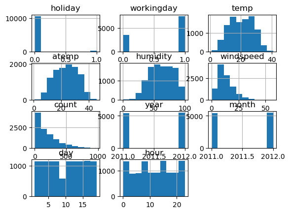

```python
# View histogram of all features again now with the hour feature
train.hist()
train.corr()
```

```python
train = train.drop(["atemp"],axis=1)
test = test.drop(["atemp"],axis=1)
```

## Step 5: Rerun the model with the same settings as before, just with more features

```python
predictor_new_features = TabularPredictor("count",eval_metric="root_mean_squared_error").fit(
    train_data = train,
    time_limit = 600,
    presets="best_quality"
)
```

```
No path specified. Models will be saved in: "AutogluonModels/ag-20240618_134315/"
Presets specified: ['best_quality']
Stack configuration (auto_stack=True): num_stack_levels=1, num_bag_folds=8, num_bag_sets=20
Beginning AutoGluon training ... Time limit = 600s
AutoGluon will save models to "AutogluonModels/ag-20240618_134315/"
AutoGluon Version:  0.8.3
Python Version:     3.10.14
Operating System:   Linux
Platform Machine:   x86_64
Platform Version:   #1 SMP Fri May 17 18:07:48 UTC 2024
Disk Space Avail:   5.16 GB / 5.36 GB (96.3%)
	WARNING: Available disk space is low and there is a risk that AutoGluon will run out of disk during fit, causing an exception.
	We recommend a minimum available disk space of 10 GB, and large datasets may require more.
Train Data Rows:    10886
Train Data Columns: 11
Label Column: count
Preprocessing data ...
AutoGluon infers your prediction problem is: 'regression' (because dtype of label-column == int and many unique label-values observed).
	Label info (max, min, mean, stddev): (977, 1, 191.57413, 181.14445)
	If 'regression' is not the correct problem_type, please manually specify the problem_type parameter during predictor init (You may specify problem_type as one of: ['binary', 'multiclass', 'regression'])
Using Feature Generators to preprocess the data ...
Fitting AutoMLPipelineFeatureGenerator...
	Available Memory:                    2034.5 MB
	Train Data (Original)  Memory Usage: 0.63 MB (0.0% of available memory)
	Inferring data type of each feature based on column values. Set feature_metadata_in to manually specify special dtypes of the features.
	Stage 1 Generators:
		Fitting AsTypeFeatureGenerator...
			Note: Converting 4 features to boolean dtype as they only contain 2 unique values.
	Stage 2 Generators:
		Fitting FillNaFeatureGenerator...
	Stage 3 Generators:
		Fitting IdentityFeatureGenerator...
		Fitting CategoryFeatureGenerator...
			Fitting CategoryMemoryMinimizeFeatureGenerator...
	Stage 4 Generators:
		Fitting DropUniqueFeatureGenerator...
	Stage 5 Generators:
		Fitting DropDuplicatesFeatureGenerator...
	Unused Original Features (Count: 1): ['month']
		These features were not used to generate any of the output features. Add a feature generator compatible with these features to utilize them.
```

[output cut: 27 more lines]

```
	'XT': [{'criterion': 'gini', 'ag_args': {'name_suffix': 'Gini', 'problem_types': ['binary', 'multiclass']}}, {'criterion': 'entropy', 'ag_args': {'name_suffix': 'Entr', 'problem_types': ['binary', 'multiclass']}}, {'criterion': 'squared_error', 'ag_args': {'name_suffix': 'MSE', 'problem_types': ['r…
	'KNN': [{'weights': 'uniform', 'ag_args': {'name_suffix': 'Unif'}}, {'weights': 'distance', 'ag_args': {'name_suffix': 'Dist'}}],
}
AutoGluon will fit 2 stack levels (L1 to L2) ...
Fitting 11 L1 models ...
Fitting model: KNeighborsUnif_BAG_L1 ... Training model for up to 399.54s of the 599.46s of remaining time.
	-124.2472	 = Validation score   (-root_mean_squared_error)
	0.02s	 = Training   runtime
	0.12s	 = Validation runtime
Fitting model: KNeighborsDist_BAG_L1 ... Training model for up to 399.36s of the 599.28s of remaining time.
	-121.1259	 = Validation score   (-root_mean_squared_error)
	0.03s	 = Training   runtime
	0.17s	 = Validation runtime
Fitting model: LightGBMXT_BAG_L1 ... Training model for up to 399.13s of the 599.05s of remaining time.
	Fitting 8 child models (S1F1 - S1F8) | Fitting with SequentialLocalFoldFittingStrategy
```

```
[1000]	valid_set's rmse: 39.8572
[2000]	valid_set's rmse: 38.2663
[3000]	valid_set's rmse: 37.691
[4000]	valid_set's rmse: 37.4434
[5000]	valid_set's rmse: 37.3788
[6000]	valid_set's rmse: 37.3325
[7000]	valid_set's rmse: 37.286
[8000]	valid_set's rmse: 37.2882
[1000]	valid_set's rmse: 40.7219
[2000]	valid_set's rmse: 39.0491
[3000]	valid_set's rmse: 38.4634
[4000]	valid_set's rmse: 38.1251
[5000]	valid_set's rmse: 37.9275
[6000]	valid_set's rmse: 37.7719
[7000]	valid_set's rmse: 37.6905
[8000]	valid_set's rmse: 37.6922
[9000]	valid_set's rmse: 37.679
[10000]	valid_set's rmse: 37.6443
[1000]	valid_set's rmse: 40.9886
[2000]	valid_set's rmse: 39.4639
[3000]	valid_set's rmse: 38.9857
[4000]	valid_set's rmse: 38.7087
[5000]	valid_set's rmse: 38.5024
[6000]	valid_set's rmse: 38.3928
[7000]	valid_set's rmse: 38.296
[8000]	valid_set's rmse: 38.2194
[9000]	valid_set's rmse: 38.129
[10000]	valid_set's rmse: 38.0989
[1000]	valid_set's rmse: 41.5519
[2000]	valid_set's rmse: 40.1043
[3000]	valid_set's rmse: 39.5398
[4000]	valid_set's rmse: 39.401
[5000]	valid_set's rmse: 39.2887
[6000]	valid_set's rmse: 39.2909
[1000]	valid_set's rmse: 43.273
[2000]	valid_set's rmse: 41.6787
[3000]	valid_set's rmse: 41.1915
[4000]	valid_set's rmse: 41.0446
[5000]	valid_set's rmse: 40.9958
[6000]	valid_set's rmse: 41.0056
```

[output cut: 10 more lines]

```
[1000]	valid_set's rmse: 42.2278
[2000]	valid_set's rmse: 41.1026
[3000]	valid_set's rmse: 40.7077
[4000]	valid_set's rmse: 40.696
[5000]	valid_set's rmse: 40.6334
[6000]	valid_set's rmse: 40.6104
[7000]	valid_set's rmse: 40.6529
[1000]	valid_set's rmse: 39.1492
[2000]	valid_set's rmse: 37.1118
[3000]	valid_set's rmse: 36.6187
[4000]	valid_set's rmse: 36.393
[5000]	valid_set's rmse: 36.2367
[6000]	valid_set's rmse: 36.2206
[7000]	valid_set's rmse: 36.2109
[8000]	valid_set's rmse: 36.2508
```

```
	-38.2879	 = Validation score   (-root_mean_squared_error)
	85.12s	 = Training   runtime
	21.98s	 = Validation runtime
Fitting model: LightGBM_BAG_L1 ... Training model for up to 277.12s of the 477.03s of remaining time.
	Fitting 8 child models (S1F1 - S1F8) | Fitting with SequentialLocalFoldFittingStrategy
```

```
[1000]	valid_set's rmse: 37.6045
[2000]	valid_set's rmse: 37.3545
[1000]	valid_set's rmse: 39.2435
[2000]	valid_set's rmse: 38.5353
[3000]	valid_set's rmse: 38.2866
[4000]	valid_set's rmse: 38.3415
[1000]	valid_set's rmse: 40.0111
[2000]	valid_set's rmse: 39.3378
[3000]	valid_set's rmse: 39.1759
[4000]	valid_set's rmse: 39.2474
[1000]	valid_set's rmse: 40.7797
[2000]	valid_set's rmse: 40.2341
[1000]	valid_set's rmse: 42.2736
[2000]	valid_set's rmse: 41.9504
[3000]	valid_set's rmse: 41.7134
[4000]	valid_set's rmse: 41.7725
[1000]	valid_set's rmse: 37.9213
[2000]	valid_set's rmse: 37.5276
[3000]	valid_set's rmse: 37.5185
[1000]	valid_set's rmse: 42.2269
[2000]	valid_set's rmse: 41.8956
[1000]	valid_set's rmse: 37.9838
[2000]	valid_set's rmse: 37.6423
```

```
	-39.2302	 = Validation score   (-root_mean_squared_error)
	43.9s	 = Training   runtime
	4.8s	 = Validation runtime
Fitting model: RandomForestMSE_BAG_L1 ... Training model for up to 221.13s of the 421.05s of remaining time.
	-43.6189	 = Validation score   (-root_mean_squared_error)
	15.58s	 = Training   runtime
	1.08s	 = Validation runtime
Fitting model: CatBoost_BAG_L1 ... Training model for up to 203.58s of the 403.5s of remaining time.
	Fitting 8 child models (S1F1 - S1F8) | Fitting with SequentialLocalFoldFittingStrategy
	Ran out of time, early stopping on iteration 1478.
	Ran out of time, early stopping on iteration 1635.
	Ran out of time, early stopping on iteration 1833.
	Ran out of time, early stopping on iteration 1836.
	Ran out of time, early stopping on iteration 1594.
	Ran out of time, early stopping on iteration 2522.
	Ran out of time, early stopping on iteration 2623.
	Ran out of time, early stopping on iteration 2769.
	-40.6954	 = Validation score   (-root_mean_squared_error)
	195.19s	 = Training   runtime
	0.13s	 = Validation runtime
Fitting model: ExtraTreesMSE_BAG_L1 ... Training model for up to 8.15s of the 208.06s of remaining time.
	-42.501	 = Validation score   (-root_mean_squared_error)
	7.11s	 = Training   runtime
	0.71s	 = Validation runtime
Completed 1/20 k-fold bagging repeats ...
Fitting model: WeightedEnsemble_L2 ... Training model for up to 360.0s of the 199.5s of remaining time.
	-37.1623	 = Validation score   (-root_mean_squared_error)
	0.57s	 = Training   runtime
	0.0s	 = Validation runtime
Fitting 9 L2 models ...
Fitting model: LightGBMXT_BAG_L2 ... Training model for up to 198.91s of the 198.9s of remaining time.
	Fitting 8 child models (S1F1 - S1F8) | Fitting with SequentialLocalFoldFittingStrategy
	-38.301	 = Validation score   (-root_mean_squared_error)
	10.07s	 = Training   runtime
	0.33s	 = Validation runtime
Fitting model: LightGBM_BAG_L2 ... Training model for up to 188.15s of the 188.14s of remaining time.
	Fitting 8 child models (S1F1 - S1F8) | Fitting with SequentialLocalFoldFittingStrategy
	-37.8314	 = Validation score   (-root_mean_squared_error)
	9.45s	 = Training   runtime
	0.12s	 = Validation runtime
```

[output cut: 22 more lines]

```
Fitting model: XGBoost_BAG_L2 ... Training model for up to 3.4s of the 3.39s of remaining time.
	Fitting 8 child models (S1F1 - S1F8) | Fitting with SequentialLocalFoldFittingStrategy
	-38.664	 = Validation score   (-root_mean_squared_error)
	3.14s	 = Training   runtime
	0.12s	 = Validation runtime
Fitting model: NeuralNetTorch_BAG_L2 ... Training model for up to 0.05s of the 0.04s of remaining time.
	Fitting 8 child models (S1F1 - S1F8) | Fitting with SequentialLocalFoldFittingStrategy
	Time limit exceeded... Skipping NeuralNetTorch_BAG_L2.
Completed 1/20 k-fold bagging repeats ...
Fitting model: WeightedEnsemble_L3 ... Training model for up to 360.0s of the -0.19s of remaining time.
	-37.0559	 = Validation score   (-root_mean_squared_error)
	0.36s	 = Training   runtime
	0.0s	 = Validation runtime
AutoGluon training complete, total runtime = 600.58s ... Best model: "WeightedEnsemble_L3"
TabularPredictor saved. To load, use: predictor = TabularPredictor.load("AutogluonModels/ag-20240618_134315/")
```

```python
predictor_new_features.fit_summary()
predictons_new_features = predictor_new_features.predict(test)
```

```
*** Summary of fit() ***
Estimated performance of each model:
                     model   score_val  pred_time_val    fit_time  pred_time_val_marginal  fit_time_marginal  stack_level  can_infer  fit_order
0      WeightedEnsemble_L3  -37.055854      30.963284  522.322553                0.000851           0.359879            3       True         16
1      WeightedEnsemble_L2  -37.162309      27.984534  340.353895                0.000943           0.571501            2       True          8
2          CatBoost_BAG_L2  -37.335631      29.036964  413.704193                0.052488          66.761182            2       True         12
3     ExtraTreesMSE_BAG_L2  -37.403355      29.796955  358.712801                0.812479          11.769790            2       True         13
4          LightGBM_BAG_L2  -37.831385      29.108636  356.395425                0.124160           9.452414            2       True         10
5   NeuralNetFastAI_BAG_L2  -37.895611      29.339240  400.698884                0.354764          53.755873            2       True         14
6   RandomForestMSE_BAG_L2  -38.009900      29.619739  386.534399                0.635263          39.591388            2       True         11
7        LightGBMXT_BAG_L1  -38.287888      21.982624   85.117666               21.982624          85.117666            1       True          3
8        LightGBMXT_BAG_L2  -38.301029      29.316733  357.017158                0.332257          10.074147            2       True          9
9           XGBoost_BAG_L2  -38.663974      29.107439  350.084441                0.122962           3.141430            2       True         15
10         LightGBM_BAG_L1  -39.230169       4.798039   43.897592                4.798039          43.897592            1       True          4
11         CatBoost_BAG_L1  -40.695439       0.125568  195.190640                0.125568         195.190640            1       True          6
12    ExtraTreesMSE_BAG_L1  -42.501039       0.709875    7.113747                0.709875           7.113747            1       True          7
13  RandomForestMSE_BAG_L1  -43.618856       1.077359   15.576496                1.077359          15.576496            1       True          5
14   KNeighborsDist_BAG_L1 -121.125931       0.167164    0.025374                0.167164           0.025374            1       True          2
15   KNeighborsUnif_BAG_L1 -124.247224       0.123847    0.021496                0.123847           0.021496            1       True          1
Number of models trained: 16
Types of models trained:
{'WeightedEnsembleModel', 'StackerEnsembleModel_LGB', 'StackerEnsembleModel_XT', 'StackerEnsembleModel_CatBoost', 'StackerEnsembleModel_KNN', 'StackerEnsembleModel_NNFastAiTabular', 'StackerEnsembleModel_RF', 'StackerEnsembleModel_XGBoost'}
Bagging used: True  (with 8 folds)
Multi-layer stack-ensembling used: True  (with 3 levels)
Feature Metadata (Processed):
(raw dtype, special dtypes):
('category', [])  : 2 | ['season', 'weather']
('float', [])     : 2 | ['temp', 'windspeed']
('int', [])       : 3 | ['humidity', 'day', 'hour']
('int', ['bool']) : 3 | ['holiday', 'workingday', 'year']
*** End of fit() summary ***
```

```python
predictons_new_features.describe()
```

```
count    6493.000000
mean      185.869766
std       173.418259
min         0.787127
25%        43.436546
50%       139.308136
75%       275.925873
max       878.618713
Name: count, dtype: float64
```

```python
# Remember to set all negative values to zero
print(sum(predictons_new_features<0))
predictons_new_features[predictons_new_features<0] = 0
```

```
0
```

```python
# Same submitting predictions
submission_new_features = pd.read_csv("sampleSubmission.csv")
submission_new_features["count"] = predictons_new_features
submission_new_features.to_csv("submission_new_features.csv", index=False)
```

```python
!kaggle competitions submit -c bike-sharing-demand -f submission_new_features.csv -m "drop atemp,new features"
```

```
Successfully submitted to Bike Sharing Demand
```

```python
!kaggle competitions submissions -c bike-sharing-demand | tail -n +1 | head -n 6
```

```
fileName                     date                 description              status    publicScore  privateScore
---------------------------  -------------------  -----------------------  --------  -----------  ------------
submission_new_features.csv  2024-06-17 12:59:21  drop atemp,new features  complete  0.42359      0.42359
submission_new_features.csv  2024-06-17 12:44:30  new features             complete  1.32363      1.32363
submission.csv               2024-06-17 12:20:08  first raw submission     complete  1.79989      1.79989
submission.csv               2024-06-17 10:47:03  first raw submission     complete  1.84007      1.84007
```

## Step 6: Hyper parameter optimization

- There are many options for hyper parameter optimization.
- Options are to change the AutoGluon higher level parameters or the individual model hyperparameters.
- The hyperparameters of the models themselves that are in AutoGluon. Those need the `hyperparameter` and `hyperparameter_tune_kwargs` arguments.

```python
hyperparameter = {
    "NN_TORCH":{},
    "GBM":[{"extra_trees": True, "ag_args": {"name_suffix": "XT"}}, {}, "GBMLarge",],
    "CAT":{},
    "XGB":{},
    "FASTAI":{},
    "RF":[{"criterion": "gini", "ag_args": {"name_suffix": "Gini", "problem_types": ["binary", "multiclass"]}}, {"criterion": "entropy", "ag_args": {"name_suffix": "Entr", "problem_types": ["binary", "multiclass"]}}, {"criterion": "squared_error", "ag_args": {"name_suffix": "MSE", "problem_types": ["regression"]}},],
    "XT":[{"criterion": "gini", "ag_args": {"name_suffix": "Gini", "problem_types": ["binary", "multiclass"]}}, {"criterion": "entropy", "ag_args": {"name_suffix": "Entr", "problem_types": ["binary", "multiclass"]}}, {"criterion": "squared_error", "ag_args": {"name_suffix": "MSE", "problem_types": ["regression"]}},],
    "KNN":[{"weights": "uniform", "ag_args": {"name_suffix": "Unif"}}, {"weights": "distance", "ag_args": {"name_suffix": "Dist"}},],
}
hyperparameter_tune_kwargs = {
    "num_trials":5,
    "scheduler":"local",
    "searcher":"auto"
}
predictor_new_hpo = TabularPredictor("count",eval_metric="root_mean_squared_error").fit(
    train_data = train,
    time_limit = 600,
    presets="best_quality",
    hyperparameters = hyperparameter,
    hyperparameter_tune_kwargs = hyperparameter_tune_kwargs
)
```

```
No path specified. Models will be saved in: "AutogluonModels/ag-20240619_141436/"
Presets specified: ['best_quality']
Warning: hyperparameter tuning is currently experimental and may cause the process to hang.
Stack configuration (auto_stack=True): num_stack_levels=1, num_bag_folds=8, num_bag_sets=20
Beginning AutoGluon training ... Time limit = 600s
AutoGluon will save models to "AutogluonModels/ag-20240619_141436/"
AutoGluon Version:  0.8.3
Python Version:     3.10.14
Operating System:   Linux
Platform Machine:   x86_64
Platform Version:   #1 SMP Fri May 17 18:07:48 UTC 2024
Disk Space Avail:   5.16 GB / 5.36 GB (96.3%)
	WARNING: Available disk space is low and there is a risk that AutoGluon will run out of disk during fit, causing an exception.
	We recommend a minimum available disk space of 10 GB, and large datasets may require more.
Train Data Rows:    10886
Train Data Columns: 11
Label Column: count
Preprocessing data ...
AutoGluon infers your prediction problem is: 'regression' (because dtype of label-column == int and many unique label-values observed).
	Label info (max, min, mean, stddev): (977, 1, 191.57413, 181.14445)
	If 'regression' is not the correct problem_type, please manually specify the problem_type parameter during predictor init (You may specify problem_type as one of: ['binary', 'multiclass', 'regression'])
Using Feature Generators to preprocess the data ...
Fitting AutoMLPipelineFeatureGenerator...
	Available Memory:                    2021.23 MB
	Train Data (Original)  Memory Usage: 0.63 MB (0.0% of available memory)
	Inferring data type of each feature based on column values. Set feature_metadata_in to manually specify special dtypes of the features.
	Stage 1 Generators:
		Fitting AsTypeFeatureGenerator...
			Note: Converting 4 features to boolean dtype as they only contain 2 unique values.
	Stage 2 Generators:
		Fitting FillNaFeatureGenerator...
	Stage 3 Generators:
		Fitting IdentityFeatureGenerator...
		Fitting CategoryFeatureGenerator...
			Fitting CategoryMemoryMinimizeFeatureGenerator...
	Stage 4 Generators:
		Fitting DropUniqueFeatureGenerator...
	Stage 5 Generators:
		Fitting DropDuplicatesFeatureGenerator...
	Unused Original Features (Count: 1): ['month']
```

[output cut: 31 more lines]

```
AutoGluon will fit 2 stack levels (L1 to L2) ...
Fitting 11 L1 models ...
Hyperparameter tuning model: KNeighborsUnif_BAG_L1 ... Tuning model for up to 32.69s of the 599.37s of remaining time.
	No hyperparameter search space specified for KNeighborsUnif_BAG_L1. Skipping HPO. Will train one model based on the provided hyperparameters.
Fitted model: KNeighborsUnif_BAG_L1 ...
	-124.2472	 = Validation score   (-root_mean_squared_error)
	0.19s	 = Training   runtime
	0.0s	 = Validation runtime
Hyperparameter tuning model: KNeighborsDist_BAG_L1 ... Tuning model for up to 32.69s of the 599.15s of remaining time.
	No hyperparameter search space specified for KNeighborsDist_BAG_L1. Skipping HPO. Will train one model based on the provided hyperparameters.
Fitted model: KNeighborsDist_BAG_L1 ...
	-121.1259	 = Validation score   (-root_mean_squared_error)
	0.16s	 = Training   runtime
	0.0s	 = Validation runtime
Hyperparameter tuning model: LightGBMXT_BAG_L1 ... Tuning model for up to 32.69s of the 598.96s of remaining time.
```

```
	Fitting 8 child models (S1F1 - S1F8) | Fitting with SequentialLocalFoldFittingStrategy
```

```
[1000]	valid_set's rmse: 39.8572
[2000]	valid_set's rmse: 38.2663
[3000]	valid_set's rmse: 37.691
```

```
	Ran out of time, early stopping on iteration 3280. Best iteration is:
	[3279]	valid_set's rmse: 37.6165
	Fitting 8 child models (S1F1 - S1F8) | Fitting with SequentialLocalFoldFittingStrategy
```

```
[1000]	valid_set's rmse: 39.5477
```

```
	Ran out of time, early stopping on iteration 1347. Best iteration is:
	[1337]	valid_set's rmse: 39.1008
	Fitting 8 child models (S1F1 - S1F8) | Fitting with SequentialLocalFoldFittingStrategy
```

```
[1000]	valid_set's rmse: 40.1502
```

```
	Ran out of time, early stopping on iteration 1274. Best iteration is:
	[1274]	valid_set's rmse: 39.2725
	Fitting 8 child models (S1F1 - S1F8) | Fitting with SequentialLocalFoldFittingStrategy
	Ran out of time, early stopping on iteration 1011. Best iteration is:
	[1011]	valid_set's rmse: 76.2508
```

```
[1000]	valid_set's rmse: 76.4888
```

```
	Fitting 8 child models (S1F1 - S1F8) | Fitting with SequentialLocalFoldFittingStrategy
	Ran out of time, early stopping on iteration 991. Best iteration is:
	[978]	valid_set's rmse: 39.1595
No model was trained during hyperparameter tuning LightGBMXT_BAG_L1... Skipping this model.
Hyperparameter tuning model: LightGBM_BAG_L1 ... Tuning model for up to 32.69s of the 583.23s of remaining time.
```

```
	Fitting 8 child models (S1F1 - S1F8) | Fitting with SequentialLocalFoldFittingStrategy
```

```
[1000]	valid_set's rmse: 37.6045
[2000]	valid_set's rmse: 37.3545
```

```
	Fitting 8 child models (S1F1 - S1F8) | Fitting with SequentialLocalFoldFittingStrategy
```

```
[1000]	valid_set's rmse: 37.7843
[1000]	valid_set's rmse: 38.4293
[1000]	valid_set's rmse: 38.2863
```

```
	Fitting 8 child models (S1F1 - S1F8) | Fitting with SequentialLocalFoldFittingStrategy
	Ran out of time, early stopping on iteration 1130. Best iteration is:
	[1050]	valid_set's rmse: 38.4394
```

```
[1000]	valid_set's rmse: 38.5057
```

```
	Fitting 8 child models (S1F1 - S1F8) | Fitting with SequentialLocalFoldFittingStrategy
	Ran out of time, early stopping on iteration 732. Best iteration is:
	[732]	valid_set's rmse: 42.7428
	Fitting 8 child models (S1F1 - S1F8) | Fitting with SequentialLocalFoldFittingStrategy
	Ran out of time, early stopping on iteration 719. Best iteration is:
	[668]	valid_set's rmse: 37.8851
No model was trained during hyperparameter tuning LightGBM_BAG_L1... Skipping this model.
Hyperparameter tuning model: RandomForestMSE_BAG_L1 ... Tuning model for up to 32.69s of the 564.22s of remaining time.
	No hyperparameter search space specified for RandomForestMSE_BAG_L1. Skipping HPO. Will train one model based on the provided hyperparameters.
Fitted model: RandomForestMSE_BAG_L1 ...
	-43.6189	 = Validation score   (-root_mean_squared_error)
	14.25s	 = Training   runtime
	0.0s	 = Validation runtime
Hyperparameter tuning model: CatBoost_BAG_L1 ... Tuning model for up to 32.69s of the 549.93s of remaining time.
```

```
	Fitting 8 child models (S1F1 - S1F8) | Fitting with SequentialLocalFoldFittingStrategy
	Ran out of time, early stopping on iteration 240.
	Ran out of time, early stopping on iteration 353.
	Ran out of time, early stopping on iteration 358.
	Ran out of time, early stopping on iteration 418.
	Ran out of time, early stopping on iteration 383.
	Ran out of time, early stopping on iteration 475.
	Ran out of time, early stopping on iteration 568.
	Ran out of time, early stopping on iteration 725.
	Stopping HPO to satisfy time limit...
Fitted model: CatBoost_BAG_L1/T1 ...
	-45.876	 = Validation score   (-root_mean_squared_error)
	28.23s	 = Training   runtime
	0.0s	 = Validation runtime
Hyperparameter tuning model: ExtraTreesMSE_BAG_L1 ... Tuning model for up to 32.69s of the 521.63s of remaining time.
	No hyperparameter search space specified for ExtraTreesMSE_BAG_L1. Skipping HPO. Will train one model based on the provided hyperparameters.
Fitted model: ExtraTreesMSE_BAG_L1 ...
	-42.501	 = Validation score   (-root_mean_squared_error)
	9.61s	 = Training   runtime
	0.0s	 = Validation runtime
Hyperparameter tuning model: NeuralNetFastAI_BAG_L1 ... Tuning model for up to 32.69s of the 511.99s of remaining time.
Will use custom hpo logic because ray import failed. Reason: ray is required to train folds in parallel. A quick tip is to install via `pip install ray==2.2.0`, or use sequential fold fitting by passing `sequential_local` to `ag_args_ensemble` when calling tabular.fitFor example: `predictor.fit(...,…
```

```
	Fitting 8 child models (S1F1 - S1F8) | Fitting with SequentialLocalFoldFittingStrategy
	Ran out of time, stopping training early. (Stopping on epoch 2)
	Ran out of time, stopping training early. (Stopping on epoch 4)
	Ran out of time, stopping training early. (Stopping on epoch 4)
	Ran out of time, stopping training early. (Stopping on epoch 6)
	Ran out of time, stopping training early. (Stopping on epoch 5)
	Ran out of time, stopping training early. (Stopping on epoch 8)
	Ran out of time, stopping training early. (Stopping on epoch 8)
	Ran out of time, stopping training early. (Stopping on epoch 8)
	Stopping HPO to satisfy time limit...
Fitted model: NeuralNetFastAI_BAG_L1/T1 ...
	-92.3071	 = Validation score   (-root_mean_squared_error)
	27.78s	 = Training   runtime
	0.0s	 = Validation runtime
Hyperparameter tuning model: XGBoost_BAG_L1 ... Tuning model for up to 32.69s of the 484.15s of remaining time.
```

```
	Fitting 8 child models (S1F1 - S1F8) | Fitting with SequentialLocalFoldFittingStrategy
	Stopping HPO to satisfy time limit...
Fitted model: XGBoost_BAG_L1/T1 ...
	-40.3925	 = Validation score   (-root_mean_squared_error)
	18.95s	 = Training   runtime
	0.0s	 = Validation runtime
Hyperparameter tuning model: NeuralNetTorch_BAG_L1 ... Tuning model for up to 32.69s of the 465.15s of remaining time.
```

```
	Fitting 8 child models (S1F1 - S1F8) | Fitting with SequentialLocalFoldFittingStrategy
	Ran out of time, stopping training early. (Stopping on epoch 9)
	Ran out of time, stopping training early. (Stopping on epoch 9)
	Ran out of time, stopping training early. (Stopping on epoch 6)
	Ran out of time, stopping training early. (Stopping on epoch 8)
	Ran out of time, stopping training early. (Stopping on epoch 7)
	Ran out of time, stopping training early. (Stopping on epoch 11)
	Ran out of time, stopping training early. (Stopping on epoch 13)
	Stopping HPO to satisfy time limit...
Fitted model: NeuralNetTorch_BAG_L1/T1 ...
	-112.7387	 = Validation score   (-root_mean_squared_error)
	28.13s	 = Training   runtime
	0.0s	 = Validation runtime
Fitting model: LightGBMLarge_BAG_L1 ... Training model for up to 32.69s of the 436.98s of remaining time.
	Fitting 8 child models (S1F1 - S1F8) | Fitting with SequentialLocalFoldFittingStrategy
```

```
[1000]	valid_set's rmse: 37.2875
```

```
	Time limit exceeded... Skipping LightGBMLarge_BAG_L1.
Repeating k-fold bagging: 2/20
Fitting model: CatBoost_BAG_L1/T1 ... Training model for up to 232.45s of the 432.33s of remaining time.
	Fitting 8 child models (S2F1 - S2F8) | Fitting with SequentialLocalFoldFittingStrategy
	Ran out of time, early stopping on iteration 2572.
	Ran out of time, early stopping on iteration 2406.
	Ran out of time, early stopping on iteration 2488.
	Ran out of time, early stopping on iteration 2383.
	Ran out of time, early stopping on iteration 2714.
	Ran out of time, early stopping on iteration 2593.
	Ran out of time, early stopping on iteration 3249.
	Ran out of time, early stopping on iteration 3397.
	-41.8504	 = Validation score   (-root_mean_squared_error)
	251.1s	 = Training   runtime
	0.13s	 = Validation runtime
Fitting model: NeuralNetFastAI_BAG_L1/T1 ... Training model for up to 9.32s of the 209.2s of remaining time.
	Fitting 8 child models (S2F1 - S2F8) | Fitting with SequentialLocalFoldFittingStrategy
	Ran out of time, stopping training early. (Stopping on epoch 0)
	Ran out of time, stopping training early. (Stopping on epoch 0)
	Ran out of time, stopping training early. (Stopping on epoch 1)
	Ran out of time, stopping training early. (Stopping on epoch 1)
	Ran out of time, stopping training early. (Stopping on epoch 1)
	Ran out of time, stopping training early. (Stopping on epoch 1)
	Ran out of time, stopping training early. (Stopping on epoch 1)
	Ran out of time, stopping training early. (Stopping on epoch 2)
	-100.1425	 = Validation score   (-root_mean_squared_error)
	36.33s	 = Training   runtime
	0.34s	 = Validation runtime
Fitting model: XGBoost_BAG_L1/T1 ... Training model for up to 0.28s of the 200.17s of remaining time.
	Fitting 8 child models (S2F1 - S2F8) | Fitting with SequentialLocalFoldFittingStrategy
	Time limit exceeded... Skipping XGBoost_BAG_L1/T1.
Fitting model: NeuralNetTorch_BAG_L1/T1 ... Training model for up to 0.17s of the 200.06s of remaining time.
	Fitting 8 child models (S2F1 - S2F8) | Fitting with SequentialLocalFoldFittingStrategy
	Time limit exceeded... Skipping NeuralNetTorch_BAG_L1/T1.
Completed 2/20 k-fold bagging repeats ...
Fitting model: WeightedEnsemble_L2 ... Training model for up to 360.0s of the 199.83s of remaining time.
	-40.5615	 = Validation score   (-root_mean_squared_error)
	0.51s	 = Training   runtime
	0.0s	 = Validation runtime
Fitting 9 L2 models ...
Hyperparameter tuning model: LightGBMXT_BAG_L2 ... Tuning model for up to 19.93s of the 199.29s of remaining time.
```

```
	Fitting 8 child models (S1F1 - S1F8) | Fitting with SequentialLocalFoldFittingStrategy
	Ran out of time, early stopping on iteration 961. Best iteration is:
	[959]	valid_set's rmse: 43.5676
	Fitting 8 child models (S1F1 - S1F8) | Fitting with SequentialLocalFoldFittingStrategy
	Ran out of time, early stopping on iteration 491. Best iteration is:
	[466]	valid_set's rmse: 42.7304
	Fitting 8 child models (S1F1 - S1F8) | Fitting with SequentialLocalFoldFittingStrategy
	Ran out of time, early stopping on iteration 236. Best iteration is:
	[214]	valid_set's rmse: 44.2907
	Ran out of time, early stopping on iteration 328. Best iteration is:
	[323]	valid_set's rmse: 42.421
	Fitting 8 child models (S1F1 - S1F8) | Fitting with SequentialLocalFoldFittingStrategy
	Ran out of time, early stopping on iteration 169. Best iteration is:
	[169]	valid_set's rmse: 82.923
	Fitting 8 child models (S1F1 - S1F8) | Fitting with SequentialLocalFoldFittingStrategy
	Ran out of time, early stopping on iteration 42. Best iteration is:
	[42]	valid_set's rmse: 47.7635
	Ran out of time, early stopping on iteration 119. Best iteration is:
	[119]	valid_set's rmse: 43.4412
	Ran out of time, early stopping on iteration 145. Best iteration is:
	[127]	valid_set's rmse: 39.7354
	Ran out of time, early stopping on iteration 143. Best iteration is:
	[143]	valid_set's rmse: 40.576
	Ran out of time, early stopping on iteration 168. Best iteration is:
	[168]	valid_set's rmse: 37.8618
	Ran out of time, early stopping on iteration 167. Best iteration is:
	[143]	valid_set's rmse: 41.7698
	Ran out of time, early stopping on iteration 151. Best iteration is:
	[145]	valid_set's rmse: 42.5458
	Ran out of time, early stopping on iteration 200. Best iteration is:
	[200]	valid_set's rmse: 40.8121
	Stopping HPO to satisfy time limit...
Fitted model: LightGBMXT_BAG_L2/T5 ...
	-41.9044	 = Validation score   (-root_mean_squared_error)
	7.2s	 = Training   runtime
	0.0s	 = Validation runtime
Hyperparameter tuning model: LightGBM_BAG_L2 ... Tuning model for up to 19.93s of the 181.36s of remaining time.
```

```
	Fitting 8 child models (S1F1 - S1F8) | Fitting with SequentialLocalFoldFittingStrategy
	Stopping HPO to satisfy time limit...
Fitted model: LightGBM_BAG_L2/T1 ...
	-40.7277	 = Validation score   (-root_mean_squared_error)
	10.3s	 = Training   runtime
	0.0s	 = Validation runtime
Hyperparameter tuning model: RandomForestMSE_BAG_L2 ... Tuning model for up to 19.93s of the 170.99s of remaining time.
	No hyperparameter search space specified for RandomForestMSE_BAG_L2. Skipping HPO. Will train one model based on the provided hyperparameters.
Fitted model: RandomForestMSE_BAG_L2 ...
	-40.7449	 = Validation score   (-root_mean_squared_error)
	41.07s	 = Training   runtime
	0.0s	 = Validation runtime
Hyperparameter tuning model: CatBoost_BAG_L2 ... Tuning model for up to 19.93s of the 129.86s of remaining time.
```

```
	Fitting 8 child models (S1F1 - S1F8) | Fitting with SequentialLocalFoldFittingStrategy
	Ran out of time, early stopping on iteration 177.
	Ran out of time, early stopping on iteration 163.
	Ran out of time, early stopping on iteration 172.
	Ran out of time, early stopping on iteration 231.
	Ran out of time, early stopping on iteration 170.
	Ran out of time, early stopping on iteration 213.
	Ran out of time, early stopping on iteration 250.
	Ran out of time, early stopping on iteration 307.
	Stopping HPO to satisfy time limit...
Fitted model: CatBoost_BAG_L2/T1 ...
	-40.6693	 = Validation score   (-root_mean_squared_error)
	17.21s	 = Training   runtime
	0.0s	 = Validation runtime
Hyperparameter tuning model: ExtraTreesMSE_BAG_L2 ... Tuning model for up to 19.93s of the 112.59s of remaining time.
	No hyperparameter search space specified for ExtraTreesMSE_BAG_L2. Skipping HPO. Will train one model based on the provided hyperparameters.
Fitted model: ExtraTreesMSE_BAG_L2 ...
	-40.0018	 = Validation score   (-root_mean_squared_error)
	13.85s	 = Training   runtime
	0.0s	 = Validation runtime
Hyperparameter tuning model: NeuralNetFastAI_BAG_L2 ... Tuning model for up to 19.93s of the 98.7s of remaining time.
```

```
	Fitting 8 child models (S1F1 - S1F8) | Fitting with SequentialLocalFoldFittingStrategy
	Ran out of time, stopping training early. (Stopping on epoch 1)
	Ran out of time, stopping training early. (Stopping on epoch 2)
	Ran out of time, stopping training early. (Stopping on epoch 1)
	Ran out of time, stopping training early. (Stopping on epoch 2)
	Ran out of time, stopping training early. (Stopping on epoch 3)
	Ran out of time, stopping training early. (Stopping on epoch 2)
	Ran out of time, stopping training early. (Stopping on epoch 3)
	Ran out of time, stopping training early. (Stopping on epoch 5)
	Stopping HPO to satisfy time limit...
Fitted model: NeuralNetFastAI_BAG_L2/T1 ...
	-45.0794	 = Validation score   (-root_mean_squared_error)
	16.74s	 = Training   runtime
	0.0s	 = Validation runtime
Hyperparameter tuning model: XGBoost_BAG_L2 ... Tuning model for up to 19.93s of the 81.89s of remaining time.
```

```
	Fitting 8 child models (S1F1 - S1F8) | Fitting with SequentialLocalFoldFittingStrategy
	Stopping HPO to satisfy time limit...
Fitted model: XGBoost_BAG_L2/T1 ...
	-41.1466	 = Validation score   (-root_mean_squared_error)
	11.18s	 = Training   runtime
	0.0s	 = Validation runtime
Hyperparameter tuning model: NeuralNetTorch_BAG_L2 ... Tuning model for up to 19.93s of the 70.64s of remaining time.
```

```
	Fitting 8 child models (S1F1 - S1F8) | Fitting with SequentialLocalFoldFittingStrategy
	Ran out of time, stopping training early. (Stopping on epoch 4)
	Ran out of time, stopping training early. (Stopping on epoch 4)
	Ran out of time, stopping training early. (Stopping on epoch 5)
	Ran out of time, stopping training early. (Stopping on epoch 6)
	Ran out of time, stopping training early. (Stopping on epoch 7)
	Ran out of time, stopping training early. (Stopping on epoch 8)
	Ran out of time, stopping training early. (Stopping on epoch 11)
	Stopping HPO to satisfy time limit...
Fitted model: NeuralNetTorch_BAG_L2/T1 ...
	-42.9947	 = Validation score   (-root_mean_squared_error)
	16.99s	 = Training   runtime
	0.0s	 = Validation runtime
Fitting model: LightGBMLarge_BAG_L2 ... Training model for up to 19.93s of the 53.6s of remaining time.
	Fitting 8 child models (S1F1 - S1F8) | Fitting with SequentialLocalFoldFittingStrategy
	Ran out of time, early stopping on iteration 446. Best iteration is:
	[161]	valid_set's rmse: 43.2762
	Ran out of time, early stopping on iteration 388. Best iteration is:
	[155]	valid_set's rmse: 44.4744
	Ran out of time, early stopping on iteration 394. Best iteration is:
	[135]	valid_set's rmse: 40.838
	Ran out of time, early stopping on iteration 410. Best iteration is:
	[345]	valid_set's rmse: 40.4919
	Ran out of time, early stopping on iteration 294. Best iteration is:
	[143]	valid_set's rmse: 41.4625
	-41.354	 = Validation score   (-root_mean_squared_error)
	18.25s	 = Training   runtime
	0.25s	 = Validation runtime
Completed 1/20 k-fold bagging repeats ...
Fitting model: WeightedEnsemble_L3 ... Training model for up to 360.0s of the 33.87s of remaining time.
	-39.837	 = Validation score   (-root_mean_squared_error)
	0.65s	 = Training   runtime
	0.0s	 = Validation runtime
AutoGluon training complete, total runtime = 566.83s ... Best model: "WeightedEnsemble_L3"
TabularPredictor saved. To load, use: predictor = TabularPredictor.load("AutogluonModels/ag-20240619_141436/")
```

```
*** Summary of fit() ***
Estimated performance of each model:
                        model   score_val  pred_time_val    fit_time  pred_time_val_marginal  fit_time_marginal  stack_level  can_infer  fit_order
0         WeightedEnsemble_L3  -39.836992       0.477471  435.656491                0.000711           0.646466            3       True         19
1        ExtraTreesMSE_BAG_L2  -40.001763       0.475271  325.498295                0.000226          13.854383            2       True         14
2           XGBoost_BAG_L1/T1  -40.392451       0.000098   18.952803                0.000098          18.952803            1       True          7
3         WeightedEnsemble_L2  -40.561478       0.134735  275.473474                0.000922           0.507204            2       True          9
4          CatBoost_BAG_L2/T1  -40.669281       0.475145  328.857950                0.000100          17.214038            2       True         13
5          LightGBM_BAG_L2/T1  -40.727718       0.475199  321.940432                0.000154          10.296520            2       True         11
6      RandomForestMSE_BAG_L2  -40.744938       0.475248  352.718078                0.000203          41.074166            2       True         12
7           XGBoost_BAG_L2/T1  -41.146586       0.475154  322.824314                0.000109          11.180402            2       True         16
8        LightGBMLarge_BAG_L2  -41.354039       0.724113  329.898726                0.249068          18.254814            2       True         18
9          CatBoost_BAG_L1/T1  -41.850381       0.133424  251.101989                0.133424         251.101989            1       True          4
10       LightGBMXT_BAG_L2/T5  -41.904424       0.475900  318.846264                0.000855           7.202352            2       True         10
11       ExtraTreesMSE_BAG_L1  -42.501039       0.000211    9.612905                0.000211           9.612905            1       True          5
```

[output cut: 39 more lines]

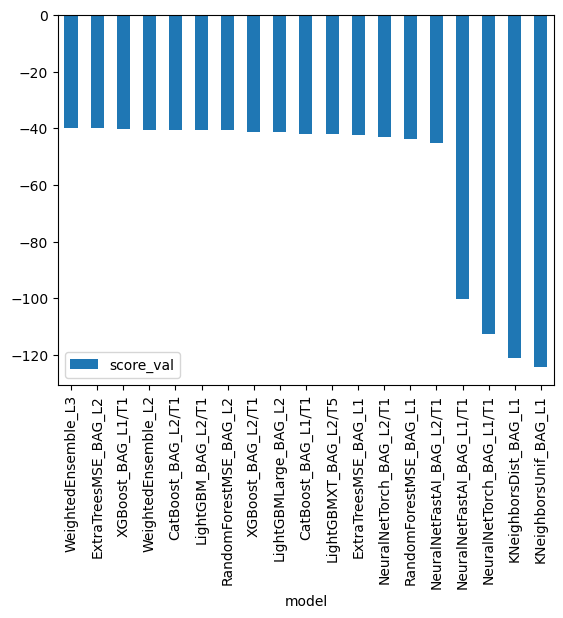

```python
predictor_new_hpo.fit_summary()
predictor_new_hpo.leaderboard().plot(x="model",y="score_val",kind="bar")
```

```python
# Remember to set all negative values to zero
predictions_hpo = predictor_new_hpo.predict(test)
sum (predictions_hpo <0)
predictions_hpo[predictions_hpo<0] = 0
```

```python
submission_new_hpo=pd.read_csv("sampleSubmission.csv")
```

```python
# Same submitting predictions
submission_new_hpo["count"] = predictions_hpo
submission_new_hpo.to_csv("submission_new_hpo.csv", index=False)
```

```python
!kaggle competitions submit -c bike-sharing-demand -f submission_new_hpo.csv -m "new features with hyperparameter tuning"
```

```
Successfully submitted to Bike Sharing Demand
```

```python
!kaggle competitions submissions -c bike-sharing-demand | tail -n +1 | head -n 6
```

```
fileName                                date                 description                              status    publicScore  privateScore
--------------------------------------  -------------------  ---------------------------------------  --------  -----------  ------------
submission_new_hpo.csv                  2024-06-19 14:24:18  new features with hyperparameter tuning  complete  0.41105      0.41105
submission_hpo_WeightedEnsemble_L2.csv  2024-06-18 15:31:16  submission_hpo_WeightedEnsemble_L2       error
submission_hpo_CatBoost_BAG_L2.csv      2024-06-18 15:27:28  submission_hpo_CatBoost_BAG_L2           complete  0.4461       0.4461
submission_hpo_WeightedEnsemble_L2.csv  2024-06-18 15:27:21  submission_hpo_WeightedEnsemble_L2       error
```

```python
predictor_new_hpo.model_names()
```

[output not shown]

```python
csv_names = []
models = ["WeightedEnsemble_L3","WeightedEnsemble_L2","CatBoost_BAG_L2"]
for model in models:
    predictions_hpo_model = predictor_new_hpo.predict(test,model=model)
    submission_new_hpo_model = pd.read_csv("sampleSubmission.csv")
    submission_new_hpo_model["count"] = predictions_hpo_model
    submission_new_hpo_model.to_csv(f"submission_hpo_{model}.csv",index=False)
    csv_names.append(f"submission_hpo_{model}.csv")
print(csv_names)
```

```
['submission_hpo_WeightedEnsemble_L3.csv', 'submission_hpo_WeightedEnsemble_L2.csv', 'submission_hpo_CatBoost_BAG_L2.csv']
```

```python
submission_2= pd.read_csv("submission_hpo_WeightedEnsemble_L2.csv")
submission_2[submission_2["count"]<0] = 0
submission_2.to_csv("submission_hpo_WeightedEnsemble_L2.csv",index=False)
```

[output not shown]

```python
!kaggle competitions submit -c bike-sharing-demand -f submission_hpo_WeightedEnsemble_L2.csv -m "submission_hpo_WeightedEnsemble_L2"
!kaggle competitions submissions -c bike-sharing-demand | tail -n +1 | head -n 6
```

```
Successfully submitted to Bike Sharing DemandfileName                                date                 description                         status    publicScore  privateScore
--------------------------------------  -------------------  ----------------------------------  --------  -----------  ------------
submission_hpo_WeightedEnsemble_L2.csv  2024-06-18 15:31:16  submission_hpo_WeightedEnsemble_L2  error
submission_hpo_CatBoost_BAG_L2.csv      2024-06-18 15:27:28  submission_hpo_CatBoost_BAG_L2      complete  0.4461       0.4461
submission_hpo_WeightedEnsemble_L2.csv  2024-06-18 15:27:21  submission_hpo_WeightedEnsemble_L2  error
submission_hpo_WeightedEnsemble_L3.csv  2024-06-18 15:27:05  submission_hpo_WeightedEnsemble_L3  complete  0.42249      0.42249
```